# DWEI5_Aula08_Flask-CustomizandoFlaskAdmin

Instituto Federal de São Paulo (IFSP)  
[Campus Bragança Paulista/SP](https://bra.ifsp.edu.br)  
**Análise e Desenvolvimento de Sistemas (ADS)**  
**5o. módulo**  
**Profa. Ana Paula Müller Giancoli**  
paulagiancoli@ifsp.edu.br

## AULA 08 - CUSTOMIZANDO A VIEW DO ADMIN E USUÁRIO

### Agenda

- Customizando o Admin
- Perguntas

### 1. Customizando o Admin

- Editar as configurações do Admin, por meio das ModelViews, personalizando.
- **ModelView**: são recursos que permitem exibir as estruturas das models como formulários no admin.
- Por meio delas, realiza-se a persistência do dados com maior facilidade.
- Ao exibir o painel do administrador, os nomes utilizados nas colunas são exatamente os utilizados como campos do banco de dados. Isso pode ser modificado. Além, de possibilitar esconder a;gum campo que não deve ser preenchido etc.
- Consulte a [documentação](https://flask-admin.readthedocs.io/en/latest/api/mod_model/#flask_admin.model.BaseModelView) para maiores detalhes e modificações.
- Algumas propriedades interessantes para serem utilizadas:
  - **column_list**: Coleção dos nomes dos campos do modelo para a exibição de lista. Se definido como None, os obterá do modelo.
  - **column_exclude_list**: Coleção de nomes de coluna da lista excluída. Logo, os nomes indicados nesta lista não serão exibidos.
  - **column_labels**: Dicionário onde a chave é o nome da coluna e o valor é a string a ser exibida.
  - **column_descriptions**: Dicionário onde a chave é o nome da coluna e o valor é a descrição da coluna de exibição de lista ou campo de adicionar / editar formulário.
  - **column_formatters**: Dicionário de formatadores de coluna de exibição de lista.
  - **column_sortable_list**: Coleção das colunas classificáveis para a exibição de lista. Se definido como None, os obterá do modelo.
  - **column_searchable_list**: Uma coleção de colunas pesquisáveis. Presume-se que apenas os campos somente de texto são pesquisáveis, mas cabe à implementação do modelo decidir.
  - **column_filters**: Coleção dos filtros da coluna.
  - **form_excluded_columns**: Coleção de nomes de campos de formulário excluídos.
  - **form_widget_args**: Dicionário de argumentos de renderização do widget de formulário. Use isso para customizar como o widget é renderizado sem usar o modelo customizado. Utilizaremos para ocultar a senha enquanto é digitada, pois o campo de senha é um texto. Podemos modificar algumas propriedades, tal como:

```
form_widget_args = {
    'description': {
        'rows': 10,
        'style': 'color: black'
    }
}
```

- Outras propriedades:
  - **on_model_change( formulário , modelo , is_created )**: É executado todas as vezes que criamos ou salvamos uma informação desse ModelView. Exemplo: ao clicar sobre o botão salvar, este método é executado.
  - **can_create**: Se False, não permite criar novos itens. Se True, habilita a função de criação.
  - **can_edit**: Se False, não permite editar os itens. Se True, habilita a função de edição.
  - **can_delete**: Se False, não permite excluir itens. Se True, habilita a função de deleção.
  - **can_view_details**: Se True, permite visuzalizar os dados daquela model sem ter que entrar no item.
  - **page_size**: quantidade de itens listados por página.
  - **can_set_page_size = True**: permite que um select seja exibido, permitindo indicar quantos itens deverão ser carregados na lista por página. True habilita, False desabilita esse select.
  - **export_types = ['json', 'yaml', 'csv', 'xls', 'df']**: formatos de exportação do relatório. Podem ser passados todos dentro da lista ou apenas os desejados.
  - **create_modal = True**: habilitará um modal com as opções selecionadas.
  - **edit_modal = True**: habilitará a edição de um modal.

### 1.1. Localize o arquivo Views.py na pasta admin

- Crie o código.
- Personalizando a View do Usuário.

```
# Componente dentro do flask_admin para ativar as views em nossa aplicação, baseadas em nossas models.
# Será utilizado aqui como superclasse da classe UsuarioView (herdará todas as configurações e poderá ser modificada)
from flask_admin.contrib.sqla import ModelView

# É importado do arquivo config.py, as variáveis app_config, app_active que app_config: possui as configurações e o tipo de ambiente a ser utilizado (Desenvolvimento, Teste ou Producao). E app_active: possui as configurações de qual ambiente está sendo utilizado por meio da variável de ambiente FLASK_ENV.
from config import app_config, app_active

# A variável config recebe a atribuição do ambiente ativo.
config = app_config[app_active]

# Classe criada para ser customizada a partir da ModelView (superclasse)
class UsuarioView(ModelView):
    # propriedades descritas anteriormente para que servem.
    column_exclude_list = ['password', 'recovery_code']
    form_excluded_columns = ['last_update', 'recovery_code']
    form_widget_args = {
        'password': {'type': 'password' }
    }

    # Método executado todas as vezes que há uma alteração: criar ou editar novo usuário.
    def on_model_change(self, form, User, is_created):
        if 'password' in form:
            # o atributo form contém todos os valores que foram inseridos no formulário da view atual
            # ou seja, se existe um campo chamado name, podemos recuperar o valor adicionado nela através de
            # form.name.data
            if form.password.data is not None:
                User.set_password(form.password.data)
            else:
                del form.password
```

### 1.2. Localize o arquivo Admin.py na pasta admin

- Modifique o código.
- Modificando a view do Admin para visualizar a view do usuário.

```
# -*- coding: utf-8 -*-
# from flask_admin import Admin: Ela possui vários recursos para criação
# de views customizadas para nossa aplicação
from flask_admin import Admin

# Componente dentro do flask_admin para ativar as views em nossa aplicação, baseadas em nossas models.
from flask_admin.contrib.sqla import ModelView
from models.Perfil import Perfil
from models.Usuario import Usuario
from models.Area import Area
from models.Modulo import Modulo
from models.Componente import Componente

# Adicionado para utilizar a view personalizada criada em Views.py (dentro da pasta admin)
# class UsuarioView(ModelView).
from admin.Views import UsuarioView                                <------ Adicione

def start_views(app, db):
    # Utilização do bootstrap4 por meio do construtor do Admin.
    admin = Admin(app, name='Componentes Curriculares', template_mode='bootstrap4')
    # Método que é utilizado para criar uma view em nossa aplicação Admin.
    # ModelView: é um recurso do flask_admin que permite a criação Admin, as telas do administrador baseadas na estrutura das models.
    # category é utilizado para agrupar nos menus.
    admin.add_view(ModelView(Perfil, db.session, "Perfis Acesso", category= "Configurações"))

    # Modificada para a view do usuario
    admin.add_view(UsuarioView(Usuario, db.session, "Usuários", category="Usuários"))

    admin.add_view(ModelView(Area, db.session, "Áreas", category="Configurações"))
    admin.add_view(ModelView(Modulo, db.session, "Módulos", category="Configurações"))
    admin.add_view(ModelView(Componente, db.session, "Componentes", category="Componentes"))
```

### 1.2.1. Visualizando as modificações

- Os campos foram omitidos tanto na lista quanto na criação, edição.
- O campo senha não é exibido como texto e sim, enquanto digita, os caracteres são omitidos.
- O campo de last_update somente será atualizado se houver modificação no usuário.

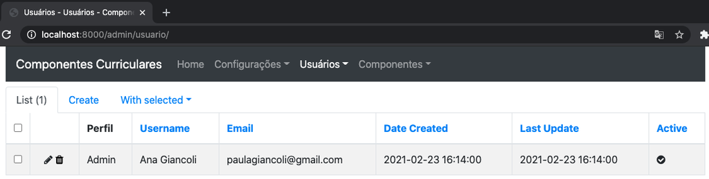

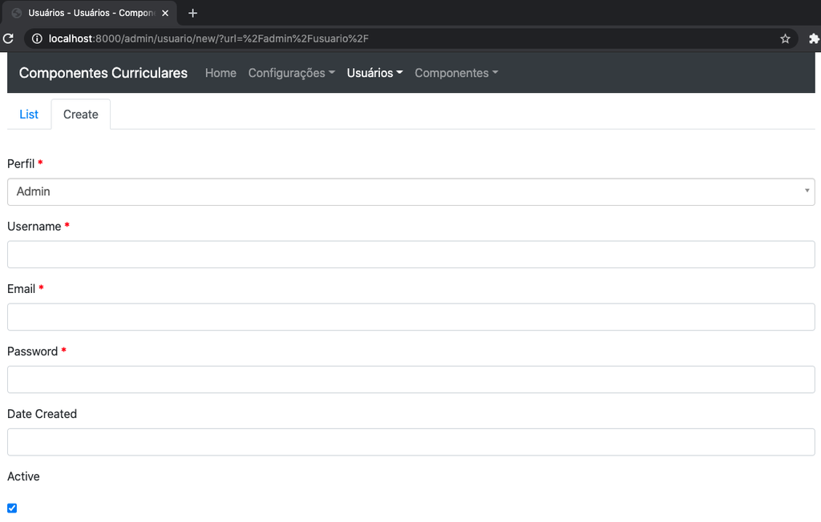

### 1.3. Modificando o arquivo Views.py da pasta admin

- Aplicando modificações na view do Usuário.

```
# Componente dentro do flask_admin para ativar as views em nossa aplicação, baseadas em nossas models.
# Será utilizado aqui como superclasse da classe UsuarioView (herdará todas as configurações e poderá ser modificada)
from flask_admin.contrib.sqla import ModelView

# É importado do arquivo config.py, as variáveis app_config, app_active que app_config: possui as configurações e o tipo de ambiente a ser utilizado (Desenvolvimento, Teste ou Producao). E app_active: possui as configurações de qual ambiente está sendo utilizado por meio da variável de ambiente FLASK_ENV.
from config import app_config, app_active

# A variável config recebe a atribuição do ambiente ativo.
config = app_config[app_active]

# Classe criada para ser customizada a partir da ModelView (superclasse)
class UsuarioView(ModelView):
    column_exclude_list = ['password', 'recovery_code']
    form_excluded_columns = ['last_update', 'recovery_code']
    form_widget_args = {
        'password': {'type': 'password' }
    }

<---- Adicione daqui pra frente ------>
    can_set_page_size = True
    can_view_details = True
    column_searchable_list = ['username', 'email']
    column_filters = ['username', 'email', 'relacao']
    column_editable_list = ['username', 'email', 'relacao', 'active' ]
    create_modal = True
    edit_modal = True
    can_export = True
    export_types = ['json', 'yaml', 'csv', 'xls', 'df']
    column_sortable_list = ['username']
    column_default_sort = ('username', True)
    column_details_exclude_list = ['password', 'recovery_code']
    column_export_exclude_list = ['password', 'recovery_code']

<---- Até ------>

    # Método executado todas as vezes que há uma alteração: criar ou editar novo usuário.
    def on_model_change(self, form, User, is_created):
        if 'password' in form:
            # o atributo form contém todos os valores que foram inseridos no formulário da view atual
            # ou seja, se existe um campo chamado name, podemos recuperar o valor adicionado nela através de
            # form.name.data
            if form.password.data is not None:
                User.set_password(form.password.data)
            else:
                del form.password
```

### 1.3.1. Visualizando as modificações

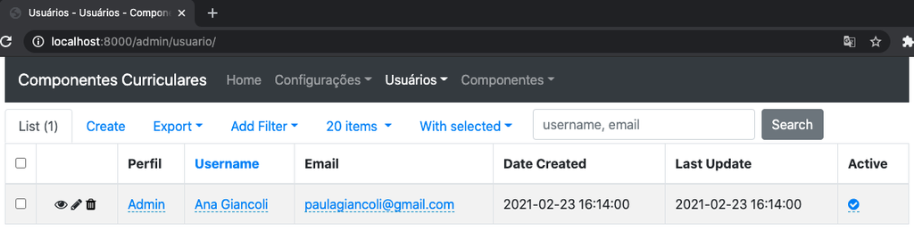

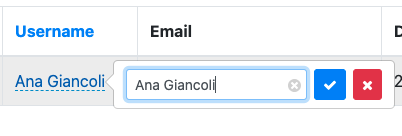

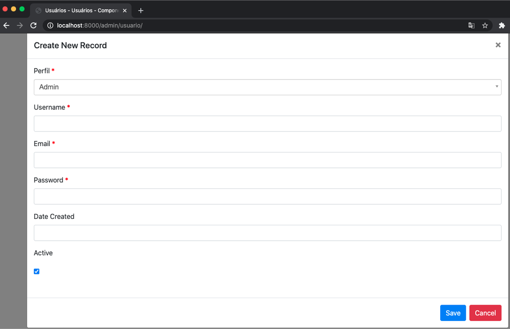

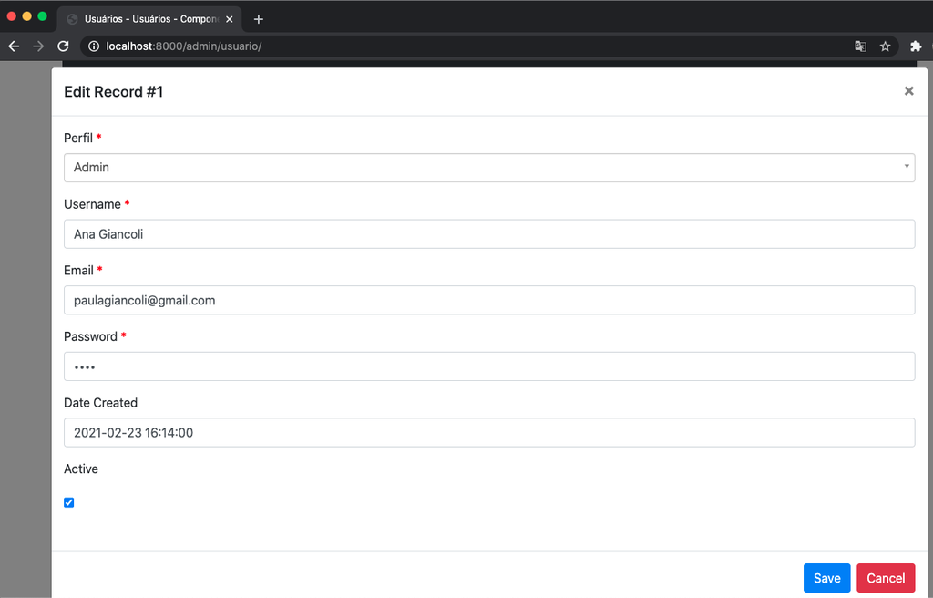

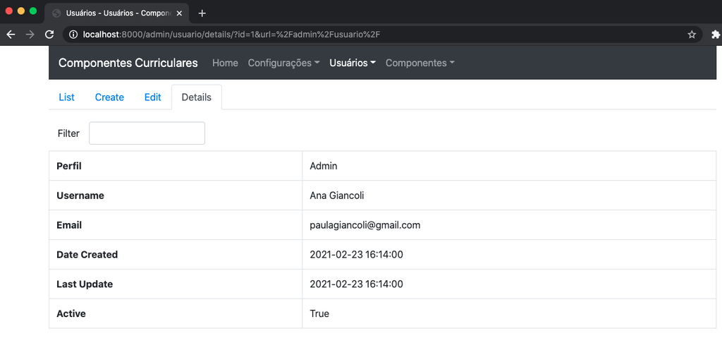

### 1.4. Localize o arquivo Views.py dentro da pasta admin

- Customizando os labels da view UsuarioView.
- Aplicando modificações na view do Usuário.

```
# Código omitido para facilitar o entendimento

class UsuarioView(ModelView):

# Código omitido para facilitar o entendimento
    column_labels = {
        'perfil': 'Perfil',
        'username': 'Nome de usuário',
        'email': 'E-mail',
        'date_created': 'Data de criação',
        'last_update': 'Última atualização',
        'active': 'Ativo',
        'password': 'Senha',
    }


    column_exclude_list = ['password', 'recovery_code']
    form_excluded_columns = ['last_update', 'recovery_code']

# Código omitido para facilitar o entendimento
```

### 1.4.1. Visualizando as modificações

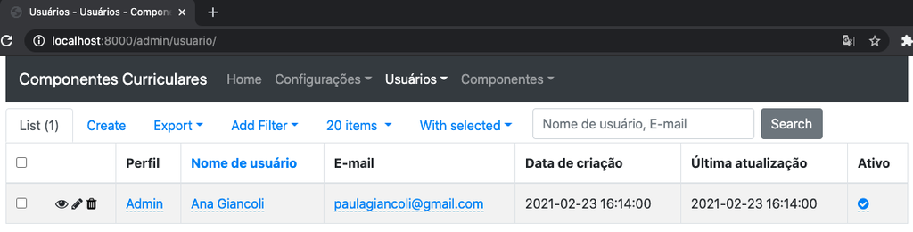

### 1.5. Localize o arquivo Views.py dentro da pasta admin

- Customizando as descrições da view UsuarioView.
- Aplicando modificações na view do Usuário.

```
# Código omitido para facilitar o entendimento

class UsuarioView(ModelView):

# Código omitido para facilitar o entendimento
    column_labels = {
        'perfil': 'Perfil',
        'username': 'Nome de usuário',
        'email': 'E-mail',
        'date_created': 'Data de criação',
        'last_update': 'Última atualização',
        'active': 'Ativo',
        'password': 'Senha',
    }

<----- Adicione esta parte ----->
    column_descriptions = {
        'perfil': 'Perfil no painel administrativo',
        'username': 'Nome de usuário no sistema',
        'email': 'E-mail do usuário no sistema',
        'date_created': 'Data de criação do usuário no sistema',
        'last_update': 'Última atualização desse usuário no sistema',
        'active': 'Estado ativo ou inativo no sistema',
        'password': 'Senha do usuário no sistema',
    }

<----- Até ----->
    column_exclude_list = ['password', 'recovery_code']
    form_excluded_columns = ['last_update', 'recovery_code']

# Código omitido para facilitar o entendimento
```

### 1.5.1. Visualizando as modificações

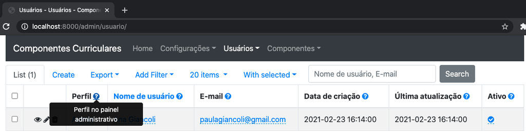

### 1.6. Localize o arquivo Admin.py dentro da pasta admin

- Incluindo a opção de saída no arquivo Admin.py.
- Para personalizar o menu, adicione o método MenuLink da biblioteca flask_admin.menu.
- O link para o Logout, aparecerá à direita. Ainda não funciona, porque não criamos a rota.

```
# Código omitido para facilitar o entendimento

# Componente dentro do flask_admin para ativar as views em nossa aplicação, baseadas em nossas models.
from flask_admin.contrib.sqla import ModelView

# Adicionado para permitir modificar o menu
from flask_admin.menu import MenuLink                                 <----- Adicione

# Código omitido para facilitar o entendimento

    # Adicione dentro do método def start_views(app, db), como última linha.
    admin.add_link(MenuLink(name='Logout', url='/logout'))
```

### 1.7. Localize o arquivo Views.py dentro da pasta admin

- Criando o Home no arquivo Views.py.

```
# Componente dentro do flask_admin para ativar as views em nossa aplicação, baseadas em nossas models.
# Será utilizado aqui como superclasse da classe UsuarioView (herdará todas as configurações e poderá ser modificada)
from flask_admin.contrib.sqla import ModelView

# Adicionado para adequar a Home da aplicação
# A classe AdminIndexView que será herdada pela classe HomeView para que a
# classe HomeView tenha todas as características da página de home
# Importando o decorator @expose('/home')para indicar qual rota está sendo modificada.
# http://localhost:8000/admin/.
from flask_admin import AdminIndexView, expose                     <------ Adicione

# É importado do arquivo config.py, as variáveis app_config, app_active que app_config: possui as configurações e o tipo de ambiente a ser utilizado (Desenvolvimento, Teste ou Producao). E app_active: possui as configurações de qual ambiente está sendo utilizado por meio da variável de ambiente FLASK_ENV.
from config import app_config, app_active

# A variável config recebe a atribuição do ambiente ativo.
config = app_config[app_active]

<----- Adicione esta parte ----->
# Adicionada a classe HomeView que herda de AdminIndexView todas as caracteírsticas.
# Substitui a home com o temnplate customizado admin.html (vamos criá-lo)
class HomeView(AdminIndexView):
    @expose('/')
    def index(self):
        return self.render('admin.html', data={ 'username': 'Ana Giancoli'})

<----- Até ----->

# Classe criada para ser customizada a partir da ModelView (superclasse)
class UsuarioView(ModelView):

    # Código omitido para facilitar o entendimento
```

- Modificando o arquivo Admin.py.
- Modificando a view do Admin para visualizar a view do Home customizada.

```
# -*- coding: utf-8 -*-
# from flask_admin import Admin: Ela possui vários recursos para criação
# de views customizadas para nossa aplicação
from flask_admin import Admin

# Componente dentro do flask_admin para ativar as views em nossa aplicação, baseadas em nossas models.
from flask_admin.contrib.sqla import ModelView

# Adicionado para permitir modificar o menu
from flask_admin.menu import MenuLink

from models.Perfil import Perfil
from models.Usuario import Usuario
from models.Area import Area
from models.Modulo import Modulo
from models.Componente import Componente

# Adicionado para utilizar a view personalizada criada em Views.py (dentro da pasta admin)
# class UsuarioView(ModelView).
from admin.Views import UsuarioView, HomeView                        <------ Adicione

def start_views(app, db):
    # Utilização do bootstrap4 por meio do construtor do Admin.
    # Modficado para usar a nova view criada: HomeView.
    # base_template: indica qual template será usado na home.
    # index_view: parâmetro que indica ao flask-admin qual será a ModelView customizada da tela home do admin.

    admin = Admin(app, name='Componentes Curriculares', base_template='admin/base.html', template_mode='bootstrap4', index_view=HomeView())                       <------ Modifique

    # Código omitido para facilitar o entendimento
```

### 1.9. Localize o arquivo admin.html dentro da pasta templates

- Criando o template da Home.
- Copie o código.
- **data.username**: passado no return da HomeView(), self.render('admin.html', data={ 'username': 'Ana Giancoli'})

```
{% extends admin_base_template %}

{% block body %}
    <h1>Seja Bem Vindo {{data.username}}</h1>
{% endblock %}
```

### 1.9.1. Visualizando as modificações

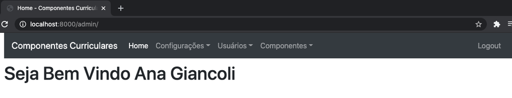

### 1.10. Localize o arquivo app.py dentro da pasta projeto

- Definindo um tema padrão.
- Para saber sobre outros temas padrões, consulte [Bootswatch](https://bootswatch.com/).

```
# Inclua

    # Adicionado para utilizar um tema padrão para o flask.
    # Outros valores: superhero, slate, cerulean, darkly, cyborg, united, sketchy
    app.config['FLASK_ADMIN_SWATCH'] = 'cerulean'

    db = SQLAlchemy(config.APP)
```

### 1.10.1. Visualizando a modificação do Tema

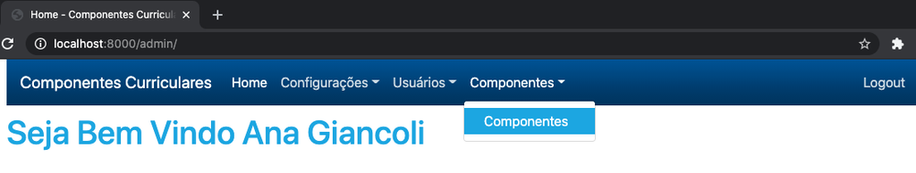

### ATENÇÃO

- **Lembre-se de encerrar o servidor ao final de cada aula**.
- **Lembre-se também, de desativar o ambiente virtual**.

### Referências

- Esta aula foi elaborada a partir do conteúdo disponibilizado em cada um dos links indicados no próprio texto.

### Perguntas

- Esclareça suas eventuais dúvidas durante as aulas.
- Ou pelo *E-mail*: paulagiancoli@ifsp.edu.br.
- Ou acesse [Github Ana Giancoli](https://anagiancoli.github.io) e solicite atendimento para o componente curricular.

*ADS - HTML5, CSS3, JS, FLASK - 5o. módulo*.  
Modelo e formato elaborado por profa. Ana Paula Müller Giancoli - BSD 2-Clause License. - Fevereiro.2021.